# Chapter 10 — Regression (R companion)

R/tidyverse translation of *Understanding Data by Alan Garfinkel and Yina Guo

Adrian Soto-Mota, MD, PhD, FACP.

2026-04-24

# Orientation

Chapter 10 (book pp. 509–556) goes from correlation to **regression**: fitting a line (or curve) and using it to predict. The book contains **no Python code listings** in this chapter. It covers OLS, absolute-value, and orthogonal regression, then moves to logistic and spline regression. We implement OLS from scratch, then use R’s `lm()` / `glm()` for the rest.

# §10.1 — Purpose of regression *(book p. 509)*

We want a rule `y ≈ f(x)`. Three uses:

1. **Describe** the trend.
2. **Predict** y at a new x.
3. **Test** whether the slope differs from zero.

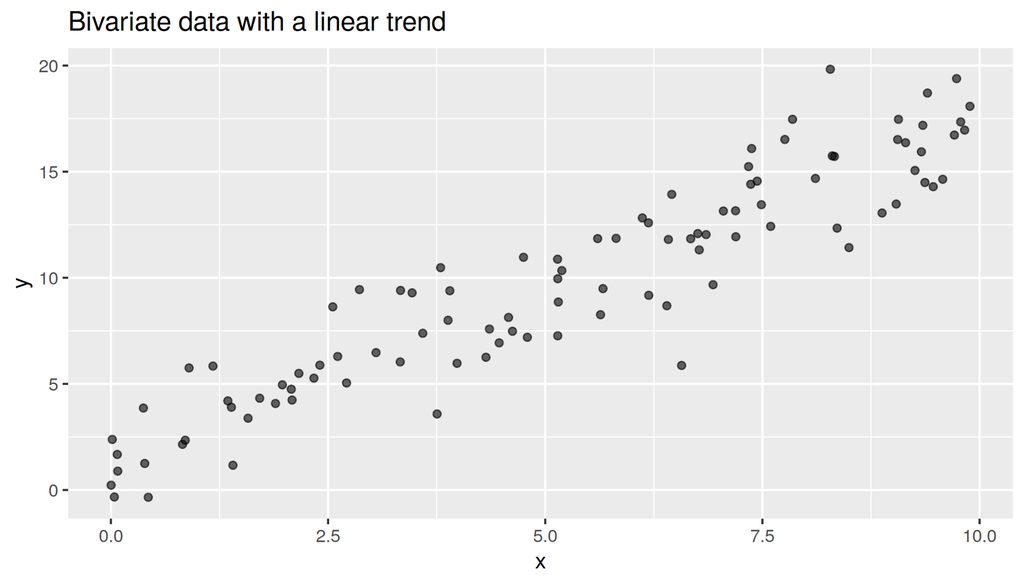

```r
n <- 100
x <- runif(n, 0, 10)
y <- 2 + 1.5 * x + rnorm(n, sd = 2)
xy <- tibble(x = x, y = y)

ggplot(xy, aes(x, y)) +
  geom_point(alpha = 0.6) +
  labs(title = "Bivariate data with a linear trend")
```

# §10.2 — Linear regression *(book p. 515)*

## Ordinary Least Squares by hand *(book §10.2 “Ordinary Least Squares regression”, p. 517)*

The OLS solution minimizes the sum of **squared vertical** residuals:

$$\hat{\beta}_1 = \frac{\sum (x_i -
\bar{x})(y_i - \bar{y})}{\sum (x_i - \bar{x})^2}, \quad
\hat{\beta}_0 = \bar{y} - \hat{\beta}_1 \bar{x}$$

```r
beta1_hat <- sum((x - mean(x)) * (y - mean(y))) /
             sum((x - mean(x))^2)
beta0_hat <- mean(y) - beta1_hat * mean(x)
c(intercept = beta0_hat, slope = beta1_hat)
```

```
## intercept     slope
##  1.492386  1.587146
```

Check against `lm()`:

```r
coef(lm(y ~ x))
```

```
## (Intercept)           x
##    1.492386    1.587146
```

## Plot the fit

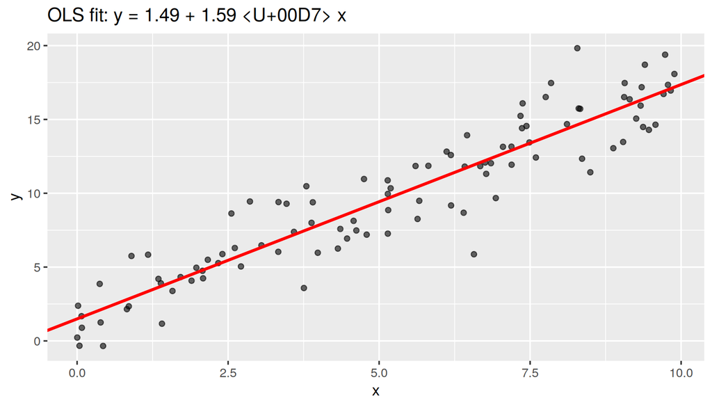

```r
ggplot(xy, aes(x, y)) +
  geom_point(alpha = 0.6) +
  geom_abline(intercept = beta0_hat, slope = beta1_hat,
              color = "red", linewidth = 1) +
  labs(title = sprintf("OLS fit: y = %.2f + %.2f × x", beta0_hat, beta1_hat))
```

## When is vertical distance the right choice? *(book §10.2 “When is it OK to use vertical distances?” and “Orthogonal regression”, pp. 516, 525)*

Vertical distance makes sense when `x` is measured precisely (or chosen) and only `y` has error. When **both** have measurement error, OLS is biased and you should use **orthogonal regression**:

```r
# Orthogonal (total least squares) via principal component
xc <- scale(xy$x, scale = FALSE)
yc <- scale(xy$y, scale = FALSE)
pc <- prcomp(cbind(xc, yc))

v          <- pc$rotation[, 1]            # first principal component
slope_orth <- v[2] / v[1]
intercept_orth <- mean(y) - slope_orth * mean(x)
c(intercept_orth = intercept_orth, slope_orth = slope_orth)
```

```
## intercept_orth     slope_orth
##       0.587033       1.759766
```

## Absolute-value (L1) regression *(book §10.2, p. 524)*

Minimize `Σ|y − (β₀ + β₁x)|` — robust to outliers.

```r
library(quantreg)   # install.packages("quantreg")
rq_fit <- rq(y ~ x, tau = 0.5)   # median regression = L1
coef(rq_fit)
```

```
## (Intercept)           x
##    1.480865    1.621734
```

```r
methods <- tibble(
  method    = c("OLS (vertical)", "Orthogonal", "L1 (median)"),
  intercept = c(beta0_hat, intercept_orth, coef(rq_fit)[1]),
  slope     = c(beta1_hat, slope_orth,     coef(rq_fit)[2])
)
methods
```

```
## # A tibble: 3 x 3
##   method         intercept slope
##   <chr>              <dbl> <dbl>
## 1 OLS (vertical)     1.49   1.59
## 2 Orthogonal         0.587  1.76
## 3 L1 (median)        1.48   1.62
```

# §10.3 — Nonlinear regression *(book p. 527)*

## Logistic regression *(book §10.3, p. 527)*

For binary outcomes. Each observation is 0/1; model the probability as `1 / (1 + exp(−(β₀ + β₁x)))`.

```r
set.seed(1)
n <- 200
x <- runif(n, -3, 3)
logit_p <- -1 + 2 * x
p <- plogis(logit_p)                  # logistic function
y <- rbinom(n, size = 1, prob = p)    # binary outcome

log_df <- tibble(x = x, y = y)

fit_log <- glm(y ~ x, data = log_df, family = binomial)
summary(fit_log)
```

```
##
## Call:
## glm(formula = y ~ x, family = binomial, data = log_df)
##
## Coefficients:
##             Estimate Std. Error z value Pr(>|z|)
## (Intercept)  -0.4728     0.2462  -1.921   0.0548 .
## x             2.0680     0.2862   7.227 4.95e-13 ***
## ---
## Signif. codes:  0 '***' 0.001 '**' 0.01 '*' 0.05 '.' 0.1 ' ' 1
##
## (Dispersion parameter for binomial family taken to be 1)
##
##     Null deviance: 276.94  on 199  degrees of freedom
## Residual deviance: 114.84  on 198  degrees of freedom
## AIC: 118.84
##
## Number of Fisher Scoring iterations: 6
```

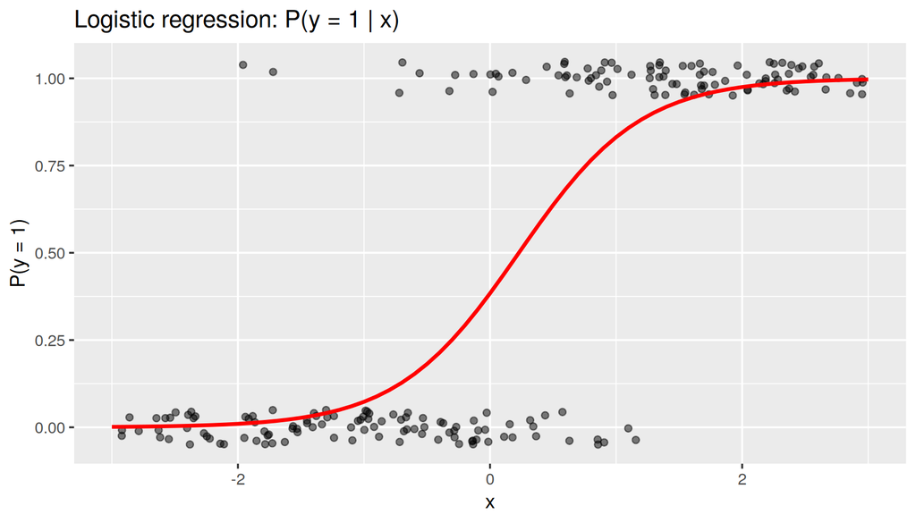

```r
pred <- tibble(x = seq(-3, 3, 0.1))
pred$p <- predict(fit_log, newdata = pred, type = "response")

ggplot(log_df, aes(x, y)) +
  geom_jitter(height = 0.05, alpha = 0.5) +
  geom_line(data = pred, aes(x, p), color = "red", linewidth = 1) +
  labs(title = "Logistic regression: P(y = 1 | x)", y = "P(y = 1)")
```

## Spline regression *(book §10.3, p. 533)*

When the relationship is curvy but you don’t know the functional form.

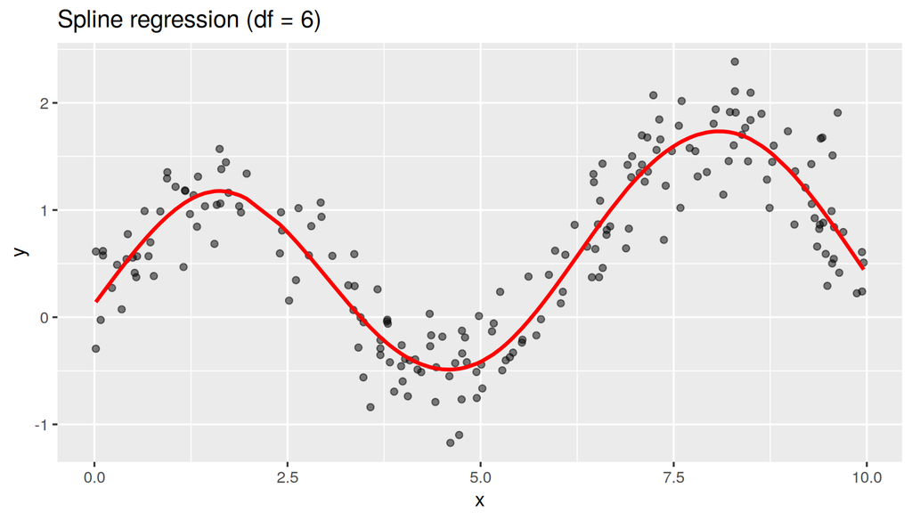

```r
n <- 200
x <- sort(runif(n, 0, 10))
y <- sin(x) + 0.1 * x + rnorm(n, sd = 0.3)

spline_df <- tibble(x = x, y = y)

# Natural cubic spline with 6 knots
library(splines)
fit_spline <- lm(y ~ ns(x, df = 6), data = spline_df)
spline_df$yhat <- predict(fit_spline)

ggplot(spline_df, aes(x, y)) +
  geom_point(alpha = 0.5) +
  geom_line(aes(y = yhat), color = "red", linewidth = 1) +
  labs(title = "Spline regression (df = 6)")
```

# §10.4 — Significance and CIs for the slope *(book p. 537)*

## Permutation test

```r
# Use the first (linear) example again
xy <- tibble(x = runif(100, 0, 10),
             y = NA)
xy$y <- 0.3 * xy$x + rnorm(100, sd = 3)   # weak true slope

obs_slope <- coef(lm(y ~ x, data = xy))[2]

n_sim <- 5000
null_slope <- numeric(n_sim)
for (i in seq_len(n_sim)) {
  shuffled <- xy
  shuffled$y <- sample(xy$y)             # break x–y link
  null_slope[i] <- coef(lm(y ~ x, data = shuffled))[2]
}

p_value <- mean(abs(null_slope) >= abs(obs_slope))
p_value
```

```
## [1] 0.005
```

## Bootstrap CI for the slope

```r
B <- 10000
boot_slope <- numeric(B)
for (i in seq_len(B)) {
  idx <- sample(seq_len(nrow(xy)), nrow(xy), replace = TRUE)
  boot_slope[i] <- coef(lm(y ~ x, data = xy[idx, ]))[2]
}
quantile(boot_slope, c(0.025, 0.975))
```

```
##       2.5%      97.5%
## 0.08304094 0.51686719
```

Compare to the parametric CI:

```r
confint(lm(y ~ x, data = xy), "x")
```

```
##        2.5 %    97.5 %
## x 0.08858161 0.5208472
```

## Wildfires example *(book §10.4 “Are wildfires increasing in CA?”, p. 540)*

```r
# Chapter's question: are California wildfires increasing?
# Simulated annual-burned-acres series:
years <- 1970:2025
acres <- 50000 + 3000 * (years - 1970) + rnorm(length(years), sd = 80000)
fires <- tibble(year = years, acres = acres)

fit <- lm(acres ~ year, data = fires)
summary(fit)$coefficients
```

```
##                Estimate   Std. Error   t value     Pr(>|t|)
## (Intercept) -7001802.69 1243215.8432 -5.632009 6.587704e-07
## year            3576.65     622.3655  5.746864 4.327953e-07
```

```r
confint(fit)
```

```
##                    2.5 %       97.5 %
## (Intercept) -9494300.385 -4509304.995
## year            2328.882     4824.418
```

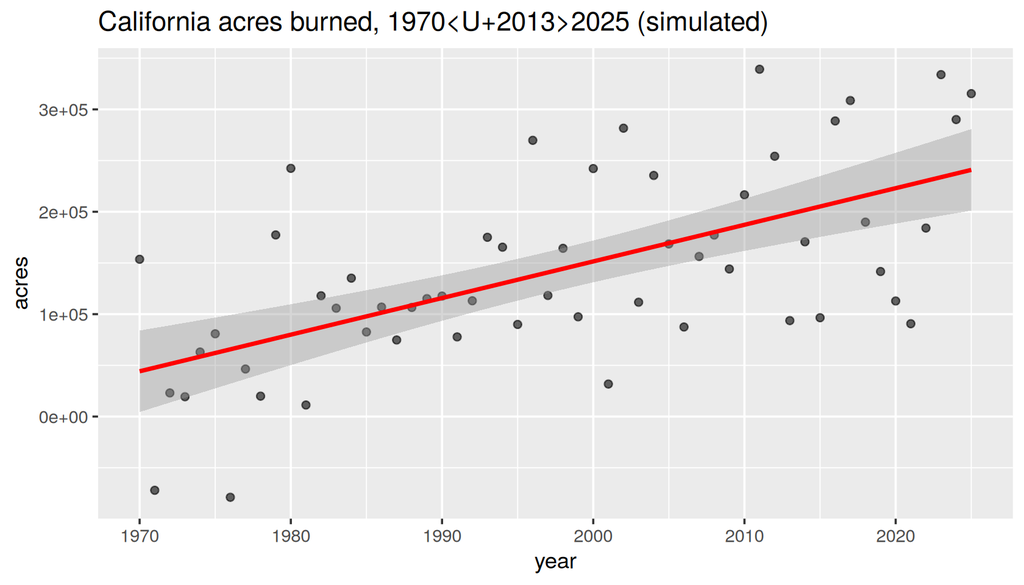

```r
ggplot(fires, aes(year, acres)) +
  geom_point(alpha = 0.6) +
  geom_smooth(method = "lm", color = "red") +
  labs(title = "California acres burned, 1970–2025 (simulated)")
```

A significant positive slope with a CI excluding zero: consistent with an increasing trend. But a LINEAR model may be too simple — try a spline and compare:

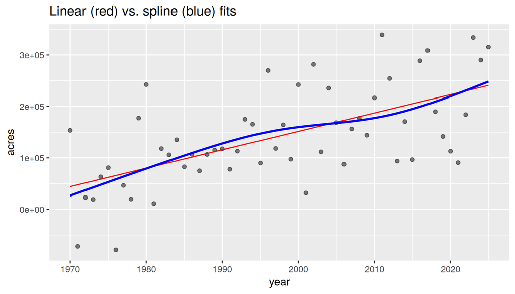

```r
fit_sp <- lm(acres ~ ns(year, df = 4), data = fires)
fires$linear <- predict(fit,    newdata = fires)
fires$spline <- predict(fit_sp, newdata = fires)

ggplot(fires, aes(year, acres)) +
  geom_point(alpha = 0.5) +
  geom_line(aes(y = linear), color = "red") +
  geom_line(aes(y = spline), color = "blue", linewidth = 1) +
  labs(title = "Linear (red) vs. spline (blue) fits")
```

The spline reveals whether the trend is linear, accelerating, or decelerating — information the linear fit hides.

# Exercises

1. Add 5 outliers at large `x`, small `y` to the linear dataset. Re-fit OLS, L1, and orthogonal. Which methods move the most? Which reflects the “honest” relationship?
2. For the logistic fit, compute the `x` at which P(y = 1) = 0.5. (Hint: set β₀ + β₁x = 0.) Add a vertical line at that `x` to the plot.
3. Fit splines with df = 3, 6, 12, 20 to the sine example. Plot all four. Discuss the bias-variance trade-off (under/over-fitting).